# Chapter 8 Homework

### Web browsing data

For this problem set, we will (again) look at the web browser history for 10k users for 1000 heavily trafficed websites. The data was obtained in the early 2000s. Each browser in the sample spent at least $1 online in the same year.

This is a simple version of the data that are used to build targeted advertising products that predict which customers are most likely to make purchases.

The data are stored in three files.  
* `browser-domains.csv` contains the counts for visits from each user ID to each website ID. * `browser-sites.txt` contains the full names of the domains for each website ID. * `browser-totalspend.csv` contains the total amount spent online that year for each user ID.

Using the code below, you can read the data and convert it into a simple triplet matrix that contains a column for every website, a row for every user, and entries that are 1 if the user visted that website and 0 otherwise. Here, we will convert this into a dense matrix as required for `prcomp`. Note that you could also use `eigen` to calculate the principal components yourself if you wanted to keep the original sparse matrix format.

```r
library(Matrix)
## Browsing History.
## The table has three colums: [machine] id, site [id], [# of] visits
web <- read.csv("browser-domains.csv")
## Read in the actual website names and relabel site factor
sitenames <- scan("browser-sites.txt", what="character")
```

```
Read 1000 items
```

```r
web$site <- factor(web$site, levels=1:length(sitenames), labels=sitenames)
## also factor machine id
web$id <- factor(web$id, levels=1:length(unique(web$id)))


## use this info in a sparse matrix
## this is something you'll be doing a lot; familiarize yourself.
xweb <- sparseMatrix(
    i=as.numeric(web$id), j=as.numeric(web$site),
# replace this with x=web$visits to have a matrix of counts instead of binary 0/1
    x=rep(1,nrow(web)),
    dims=c(nlevels(web$id),nlevels(web$site)),
    dimnames=list(id=levels(web$id), site=levels(web$site)))


# what sites did household 1 visit?
head(xweb[1, xweb[1,]!=0])
```

```
         atdmt.com          yahoo.com            msn.com
                 1                  1                  1
        google.com            aol.com questionmarket.com
                 1                  1                  1
```

```r
## now read in the spending data
yspend <- read.csv("browser-totalspend.csv", row.names=1)  # us 1st column as row names
yspend <- as.matrix(yspend) ## good practice to move from dataframe to matrix

# finally, convert to dense
x <- as.matrix(xweb)
```

**Fit PCA on `xweb`. Produce the screeplot showing the variation in the first few PCs.**

```r
pca <- prcomp(x, scale=TRUE)
sort(pca$rotation[,1])[1:10]
```

```
        thinktarget.com             valuead.com
            -0.06281455             -0.06157459
           clicksor.com            paypopup.com
            -0.06149576             -0.06070153
             revsci.net      mobilesidewalk.com
            -0.06047592             -0.06037046
        contextuads.com liquidmedianetworks.com
            -0.06006839             -0.05995274
              adecn.com          partypoker.com
            -0.05963790             -0.05953537
```

```r
sort(pca$rotation[,1], decreasing=TRUE)[1:10]
```

```
    64.136.28.49      authnow.com         eimg.net         acsd.exe
    0.0145642954     0.0082084483     0.0036864659     0.0033956682
    aolwbspd.exe netzerovoice.com      aol.com-o07 cometsystems.com
    0.0030818855     0.0023935027     0.0019464198     0.0014704314
     postini.com      lanxtra.com
    0.0009414876     0.0005669447
```

```r
sort(pca$rotation[,2])[1:10]
```

```
citysearch.com       usps.com superpages.com    weather.com
   -0.06543370    -0.06228797    -0.05996208    -0.05842693
     lowes.com      about.com whitepages.com        rs6.net
   -0.05777673    -0.05761843    -0.05740661    -0.05681809
 homedepot.com      sears.com
   -0.05647246    -0.05640103
```

```r
sort(pca$rotation[,2], decreasing=TRUE)[1:10]
```

```
          amaena.com         64.39.16.166          passion.com
          0.07716440           0.07554578           0.07388573
             888.com pcsecurityshield.com     myriadmarket.com
          0.07257131           0.07235797           0.07193656
 shopyourbargain.com        errorsafe.com     winantivirus.com
          0.07158673           0.06897519           0.06774307
           rootv.com
          0.06665457
```

From the largest and smallest loadings in the first two factors, it is not easy to see how to interpret these. Looking at the summary,

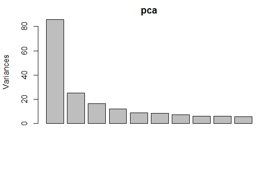

```r
plot(pca)
```

The drop off in variation after the first PC is large.

**Sample a random test sample of 1000 observations. Compare out-of-sample predicted log spending on this test sample using the lasso model of the problem set for Chapter 3 and a GLM onto the first 10 PCs.**

First, split the data into test and train.

```r
set.seed(1)
testi <- sample.int(nrow(x),1000)
V <- as.data.frame(predict(pca)[,1:10])
fitPC <- glm(log(yspend)[-testi] ~ ., data= V[-testi,])
summary(fitPC)
```

```
Call:
glm(formula = log(yspend)[-testi] ~ ., data = V[-testi, ])

Deviance Residuals:
    Min       1Q   Median       3Q      Max
-6.3090  -0.9646   0.0400   1.0196   7.4187

Coefficients:
             Estimate Std. Error t value Pr(>|t|)
(Intercept)  6.193743   0.016255 381.032  < 2e-16 ***
PC1         -0.023714   0.001758 -13.487  < 2e-16 ***
PC2         -0.089788   0.003228 -27.816  < 2e-16 ***
PC3          0.025460   0.004017   6.338 2.44e-10 ***
PC4         -0.038930   0.004690  -8.301  < 2e-16 ***
PC5         -0.065246   0.005394 -12.097  < 2e-16 ***
PC6         -0.003184   0.005642  -0.564   0.5726
PC7         -0.096349   0.006032 -15.973  < 2e-16 ***
PC8         -0.012400   0.006476  -1.915   0.0555 .
PC9         -0.002152   0.006670  -0.323   0.7470
PC10        -0.063909   0.006787  -9.416  < 2e-16 ***
---
Signif. codes:  0 ‘***’ 0.001 ‘**’ 0.01 ‘*’ 0.05 ‘.’ 0.1 ‘ ’ 1

(Dispersion parameter for gaussian family taken to be 2.377806)

    Null deviance: 25085  on 8999  degrees of freedom
Residual deviance: 21374  on 8989  degrees of freedom
AIC: 33349

Number of Fisher Scoring iterations: 2
```

```r
## OOS MSE for PCR
yhatPC <- predict(fitPC, V[testi,])
mean( (log(yspend)[testi]-yhatPC)^2 )
```

```
[1] 2.400021
```

```r
## OOS MSE for Lasso
library(gamlr)
spender <- gamlr(xweb[-testi,], log(yspend)[-testi])
yhatLasso <- predict(spender, xweb[testi,])
mean( (log(yspend)[testi]-yhatLasso)^2 )
```

```
[1] 2.148184
```